# h2pdis_jcr

```python
%matplotlib inline

import math
import os
import matplotlib as mpl
import matplotlib.pyplot as plt
import numpy as np
import amjuel
import ehr
import xsection as xs
```

We use the H collisional radiative code *collrad* to model the fate of the products of H$_{2}^{+}$ dissociation:

$\frac{N_{n}}{n_{H_{2}^{+}}} = - (Q^{-1})_{nm} E_{H_{2}^+,m} - (Q^{-1})_{nm} \alpha_{m} \equiv R_{H}^{H_{2}^{+}}(p) + R_{2H}^{H_{2}^{+}}(p)$,

The first of the two terms on the right hand side represents the products of dissociative excitation. The Janev, Langer, Evans and Post (JLEP) dissociative excitation process (2.2.13) provided only the production rate of $n=2$ atoms. Reiter's 1992 PSI paper proposed an *ad hoc* procedure for estimating the $n=3$ production rate, which was used in DEGAS and then in the initial implementation of this process in DEGAS 2. Reiter now instead uses Sawada's code which has a hardwired $1/n^{3}$ scaling for the higher states so that:

$E_{H_{2}^+,m} = [1, (2/3)^3, (2/4)^{3}, ... (2/m)^{3} ... ] < \sigma v>_{(2.2.13)}$.

The second term on the right hand side corresponds to dissociative recombination, (2.2.14). In this case, JLEP does provide a scaling:

$\alpha_{m} = [0.1, 0.45, 0.22, 0.12, 0.069, ... (10/m^{3}) ... ] < \sigma v>_{(2.2.14)}$.

Using the notation from Kotov's thesis, we can then write out the expression for the **effective dissociation rate for H$_{2}^{+}$**:

$D_{H_{2}^{+}} = C_{H_{2}^{+}} + \sum_{p^{\prime} > 1} \{ S_{H}(p^{\prime}) R_{2H}^{H_{2}^{+}}(p^{\prime}) + [A_{H}(p^{\prime},1)/n_{e} + F_{H}(p^{\prime},1)] R_{H}^{H_{2}^{+}}(p^{\prime}) \}$.

The first term, $C_{H_{2}^{+}} = < \sigma v>_{(2.2.12)}$, represents dissociation of H$_{2}^{+}$ with the resulting atom going into the ground state; *note that this term is missing from Kotov's equation, although it is mentioned in the text.* The second term represents the products of dissociative recombination that end up getting ionized; this is the loss term in the expression for $R_{H_{2}^{+}}$. Note that Kotov's thesis has a typo here, with $E_{H_{2}^{+}}$ instead of $S_{H}$. The third term represents the products of dissociative excitation that decay or are de-excited to the ground state.

We have incorporated these terms into *collrad*, and we can get $S_{H_{2}^{+}}$ from its *fort.19* file:

```python
h2cr_19_saw = ehr.ehr_data('fort.19')
print(h2cr_19_saw.data_dict.keys())
```

```
dict_keys(['  H2 Dissociation Rate(jt,jn) (cm**3 s**-1)  Te(jt) = 10**(-1.2 + (jt-1)/10) jt=1,60\n', '  H2 Dissociative Ionization Rate(jt,jn) (cm**3 s**-1)\n', '  H2+ Dissociative Recombination Rate(jt,jn)  (cm**3 s**-1)\n', '  H2+ Dissociation Rate(jt,jn)  (cm**3 s**-1)\n', '  H2+ Dissociative Ion…
```

```python
D_H2p = h2cr_19_saw.get_one_var('H2+ Dissociation Rate')
```

We read in the corresponding rates from AMJUEL only for verification:

```python
amj_file = 'amjuel.tex'
```

Use the same grid for the two sets of data.

```python
ehr19Te = h2cr_19_saw.get_Te()
ehr19ne = h2cr_19_saw.get_ne()
num_Te = ehr19Te.shape[0]
num_ne = ehr19ne.shape[0]
```

```python
H123 = 'H.4'
reacstr = '2.2.12'
fit_coef = amjuel.get_AMJUEL_fit(amj_file,H123,reacstr)
data_2212 = np.zeros((num_ne,num_Te))
for jt in range(num_Te):
    for jn in range(num_ne):
        data_2212[jn,jt] = amjuel.ne_Te_exp_fit(fit_coef,ehr19ne[jn],ehr19Te[jt])
```

We will be comparing with the reaction rate previously used by DEGAS 2 for this process, which was obtained by evaluating the fit for JLEP reaction (2.2.12). Note that it has neither the second or third terms in the above expression for the effective reaction rate.

```python
data_dir = '../'
h2pdis_nc = xs.xs_netCDF.read_ncfile('h2pdis',data_dir)
h2pdis_nc.xs.list_vars()
print('  ')
h2pdis_nc.xs.print_var(0)
old_rate = h2pdis_nc.xs.get_var4plot(0)
print('  ')
h2pdis_nc.xs.print_var(2)
old_eloss = h2pdis_nc.xs.get_var4plot(2)
```

```
 j              Name                   Units
 0 reaction_rate                  cm^3/s
 1 dissociation_energy            eV
 2 background_energy_loss_rate    eV*cm^3/s

Dependent variable:  reaction_rate  Units:  cm^3/s
 Multiplier:  1.00000e-06  Spacing:  log

  Indep. var.     Units    Multiplier  Spacing     Min.        Max.
temperature     eV         1.60218e-19 log      1.00000e+00 5.01187e+04

Dependent variable:  background_energy_loss_rate  Units:  eV*cm^3/s
 Multiplier:  1.60218e-25  Spacing:  log

  Indep. var.     Units    Multiplier  Spacing     Min.        Max.
temperature     eV         1.60218e-19 log      1.00000e+00 5.01187e+04
```

Make a comparison plot.

The designation "JCR" here and in the name of this and the other associated molecular dissociation reaction files stands for "Janev Collisional Radiative" since the original approach was to use the Janev rates for the dissociative excitation product distribution in *collrad*.

The previous DEGAS 2 rate for this process, without collisional radiative effects, is included for comparison. Again, this is lower at higher $T_{e}$ since it lacks contributions from the decay or de-excitation of dissociative excitation products.

The different colors represent different densities, as is indicated by the legend.

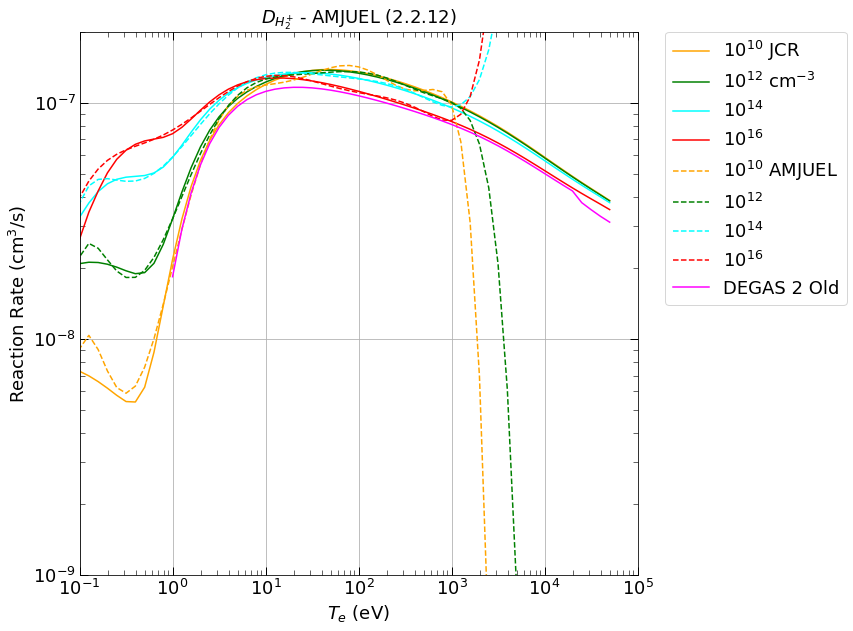

```python
plt.figure(figsize=(10,10))
plt.plot(ehr19Te,D_H2p[0,:],label='$10^{10}$ JCR',color='orange')
plt.plot(ehr19Te,D_H2p[4,:],label='$10^{12}$ cm$^{-3}$',color='green')
plt.plot(ehr19Te,D_H2p[8,:],label='$10^{14}$',color='cyan')
plt.plot(ehr19Te,D_H2p[12,:],label='$10^{16}$',color='red')
plt.plot(ehr19Te,data_2212[0,:],label='$10^{10}$ AMJUEL',ls='--',color='orange')
plt.plot(ehr19Te,data_2212[4,:],label='$10^{12}$',ls='--',color='green')
plt.plot(ehr19Te,data_2212[8,:],label='$10^{14}$',ls='--',color='cyan')
plt.plot(ehr19Te,data_2212[12,:],label='$10^{16}$',ls='--',color='red')
plt.plot(old_rate[0],old_rate[1],label='DEGAS 2 Old',color='magenta')
plt.xlabel('$T_{e}$ (eV)',fontsize=18)
plt.ylabel('Reaction Rate (cm$^{3}$/s)',fontsize=18)
plt.tick_params(which='major',labelsize=18,length=8,width=1,
                direction='in',top='on',right='on')
plt.tick_params(which='minor',length=5,
                direction='in',top='on',right='on')
plt.minorticks_on()
plt.gca().set_yscale('log')
plt.gca().set_xscale('log')
plt.gca().set_xlim((0.1,1.e5))
plt.gca().set_ylim((1.e-9,2.e-7))
plt.gca().grid(axis='both',which='major')
plt.title('$D_{H_{2}^{+}}$ - AMJUEL (2.2.12)',fontsize=18)
plt.legend(bbox_to_anchor=(1.05,1),loc='upper left',borderaxespad=0,fontsize=18)
```

The rapid variations in the AMJUEL rates, e.g., below 1 eV and between $10^{2}$ and $10^{3}$ eV, may be artifacts of the polynomial fits. In particular, this process has contributions associated with the two JLEP processes, (2.2.13) and (2.2.14), which have very different temperature dependencies, presenting a greater challenge to the fitting algorithm.

For the energetics, using the same approach as the original model, which is the same as that used by EIRENE. Namely, the energy of dissociation products, $E_{diss} = 4.3$ eV and electron cooling per dissociation, $E_{loss} = 10.5$ eV. That latter is used to compute an effective background energy loss rate.

```python
E_diss = 4.3
E_loss = 10.5
E_loss_rate = E_loss * D_H2p
```

Compare this loss rate with the one previously used by DEGAS 2 for this reaction:

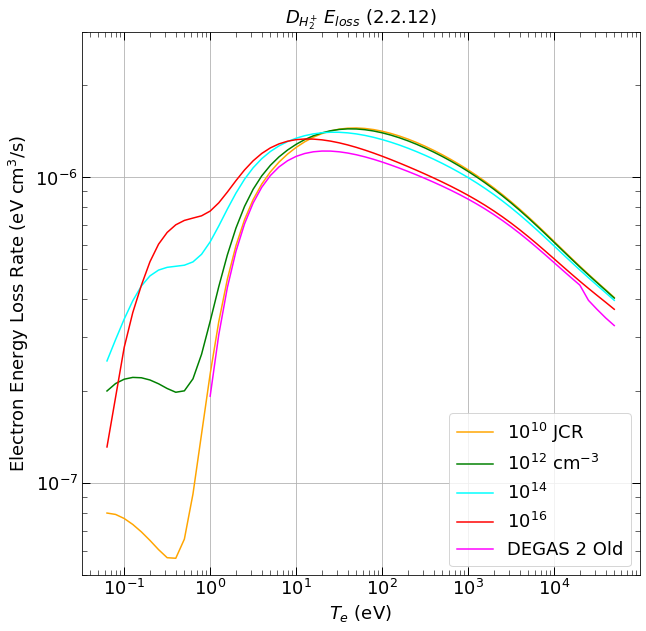

```python
plt.figure(figsize=(10,10))
plt.plot(ehr19Te,E_loss_rate[0,:],
         label='$10^{10}$ JCR',color='orange')
plt.plot(ehr19Te,E_loss_rate[4,:],
         label='$10^{12}$ cm$^{-3}$',color='green')
plt.plot(ehr19Te,E_loss_rate[8,:],
         label='$10^{14}$',color='cyan')
plt.plot(ehr19Te,E_loss_rate[12,:],
         label='$10^{16}$',color='red')
plt.plot(old_eloss[0],old_eloss[1],label='DEGAS 2 Old',color='magenta')
plt.xlabel('$T_{e}$ (eV)',fontsize=18)
plt.ylabel('Electron Energy Loss Rate (eV cm$^{3}$/s)',fontsize=18)
plt.tick_params(which='major',labelsize=18,length=8,width=1,
                direction='in',top='on',right='on')
plt.tick_params(which='minor',length=5,
                direction='in',top='on',right='on')
plt.minorticks_on()
plt.gca().set_yscale('log')
plt.gca().set_xscale('log')
#plt.gca().set_xlim((1.,1.e3))
plt.gca().set_ylim((5.e-8,3.e-6))
plt.gca().grid(axis='both',which='major')
plt.title('$D_{H_{2}^{+}}$ $E_{loss}$ (2.2.12)',fontsize=18)
plt.legend(fontsize=18)
```

As is done for H CR data, e.g., in hionize5.nc, we provide the emission rate for photons, as a power, rather than the excited state population coefficients. First, extract the data for all excited states from the file. Since AMJUEL only provides a fit for the combination of the dissociative excitation and recombination, we read in the *collrad* data for both, then plot the sum and the excitation portion (an analogous plot in the h2pdisrec_jcr.ipynb notebook isolates the contribution from recombination). Note that there are data for $n = 2 \rightarrow 9 \Rightarrow 8$ states.

```python
H2p_exc_popn_coef = np.zeros((num_ne,num_Te,8))
H2p_rec_popn_coef = np.zeros((num_ne,num_Te,8))
for n in range(2,10):
    print(n)
    H2p_exc_popn_coef[:,:,n-2] = h2cr_19_saw.get_one_var('H2+ Dissociative Excitation n='+str(n))
    H2p_rec_popn_coef[:,:,n-2] = h2cr_19_saw.get_one_var('H2+ Dissociative Recombination n='+str(n))
```

```
2
3
4
5
6
7
8
9
```

AMJUEL provides the population coefficients, so we use that for the comparison plots:

```python
H123 = 'H.12'
reacstr = '2.2.14a'
fit_coef = amjuel.get_AMJUEL_fit(amj_file,H123,reacstr)
data_2214a = np.zeros((num_ne,num_Te))
for jt in range(num_Te):
    for jn in range(num_ne):
        data_2214a[jn,jt] = amjuel.ne_Te_exp_fit(fit_coef,ehr19ne[jn],ehr19Te[jt])
```

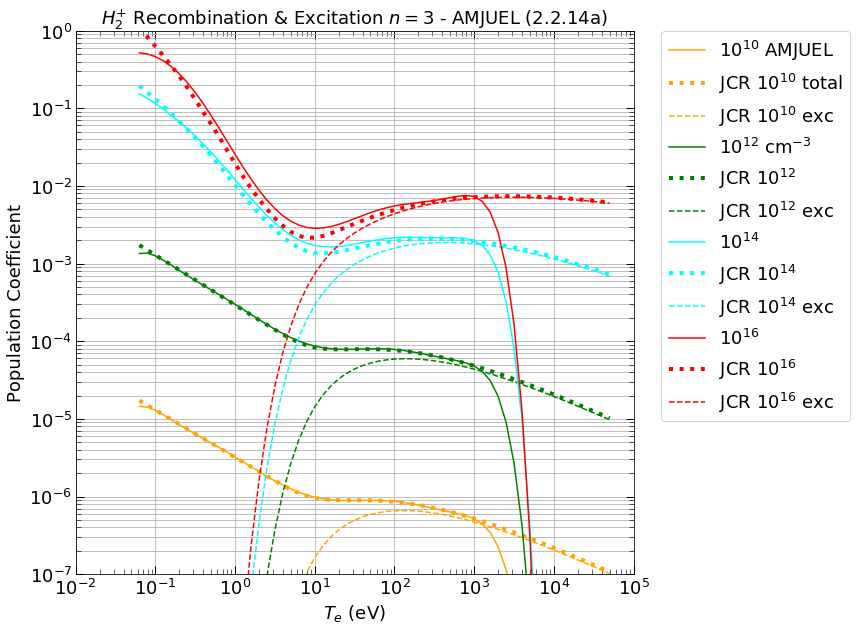

```python
plt.figure(figsize=(10,10))
plt.plot(ehr19Te,data_2214a[0,:],label='$10^{10}$ AMJUEL',color='orange')
plt.plot(ehr19Te,
         (H2p_rec_popn_coef[0,:,1]+H2p_exc_popn_coef[0,:,1]),
         label='JCR $10^{10}$ total',color='orange',lw=4,ls=':')
plt.plot(ehr19Te,
         (H2p_exc_popn_coef[0,:,1]),
         label='JCR $10^{10}$ exc',color='orange',ls='--')
plt.plot(ehr19Te,data_2214a[4,:],label='$10^{12}$ cm$^{-3}$',color='green')
plt.plot(ehr19Te,
         (H2p_rec_popn_coef[4,:,1]+H2p_exc_popn_coef[4,:,1]),
         label='JCR $10^{12}$',color='green',lw=4,ls=':')
plt.plot(ehr19Te,
         (H2p_exc_popn_coef[4,:,1]),
         label='JCR $10^{12}$ exc',color='green',ls='--')
plt.plot(ehr19Te,data_2214a[8,:],label='$10^{14}$',color='cyan')
plt.plot(ehr19Te,
         (H2p_rec_popn_coef[8,:,1]+H2p_exc_popn_coef[8,:,1]),
         label='JCR $10^{14}$',color='cyan',lw=4,ls=':')
plt.plot(ehr19Te,
         (H2p_exc_popn_coef[8,:,1]),
         label='JCR $10^{14}$ exc',color='cyan',ls='--')
plt.plot(ehr19Te,data_2214a[12,:],label='$10^{16}$',color='red')
plt.plot(ehr19Te,
         (H2p_rec_popn_coef[12,:,1]+H2p_exc_popn_coef[12,:,1]),
         label='JCR $10^{16}$',color='red',lw=4,ls=':')
plt.plot(ehr19Te,
         (H2p_exc_popn_coef[12,:,1]),
         label='JCR $10^{16}$ exc',color='red',ls='--')
plt.xlabel('$T_{e}$ (eV)',fontsize=18)
plt.ylabel('Population Coefficient',fontsize=18)
plt.tick_params(which='major',labelsize=18,length=8,width=1,
                direction='in',top='on',right='on')
plt.tick_params(which='minor',length=5,
                direction='in',top='on',right='on')
plt.minorticks_on()
plt.gca().set_yscale('log')
plt.gca().set_xscale('log')
plt.gca().set_xlim((0.01,1.e5))
plt.gca().set_ylim((1.e-7,1.0))
plt.gca().grid(axis='both',which='major')
plt.gca().grid(axis='y',which='minor')
plt.title('$H_{2}^{+}$ Recombination & Excitation $n=3$ - AMJUEL (2.2.14a)',fontsize=18)
plt.legend(bbox_to_anchor=(1.05,1),loc='upper left',borderaxespad=0,fontsize=18)
```

```python
H123 = 'H.12'
reacstr = '2.2.14b'
fit_coef = amjuel.get_AMJUEL_fit(amj_file,H123,reacstr)
data_2214b = np.zeros((num_ne,num_Te))
for jt in range(num_Te):
    for jn in range(num_ne):
        data_2214b[jn,jt] = amjuel.ne_Te_exp_fit(fit_coef,ehr19ne[jn],ehr19Te[jt])
```

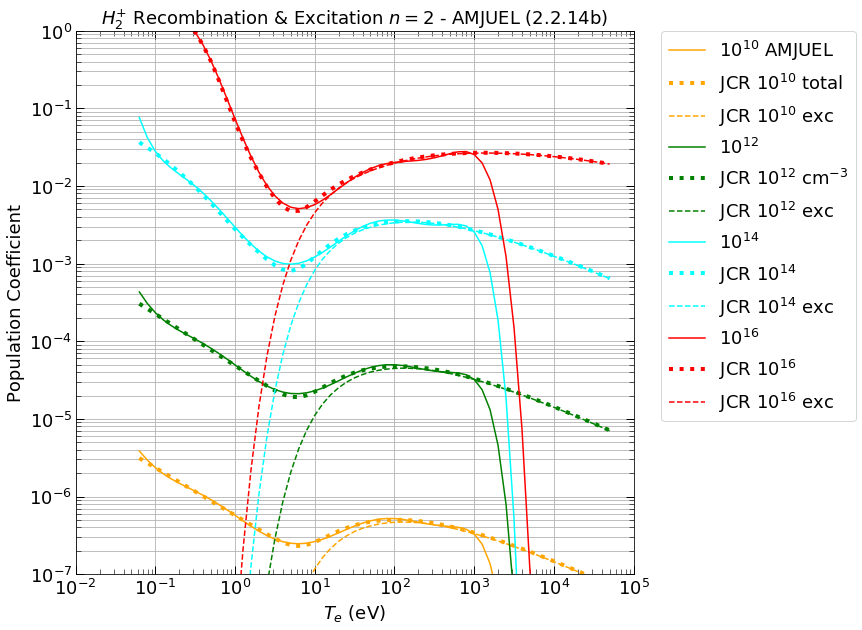

```python
plt.figure(figsize=(10,10))
plt.plot(ehr19Te,data_2214b[0,:],label='$10^{10}$ AMJUEL',color='orange')
plt.plot(ehr19Te,
         (H2p_rec_popn_coef[0,:,0]+H2p_exc_popn_coef[0,:,0]),
         label='JCR $10^{10}$ total',color='orange',lw=4,ls=':')
plt.plot(ehr19Te,
         (H2p_exc_popn_coef[0,:,0]),
         label='JCR $10^{10}$ exc',color='orange',ls='--')
plt.plot(ehr19Te,data_2214b[4,:],label='$10^{12}$',color='green')
plt.plot(ehr19Te,
         (H2p_rec_popn_coef[4,:,0]+H2p_exc_popn_coef[4,:,0]),
         label='JCR $10^{12}$ cm$^{-3}$',color='green',lw=4,ls=':')
plt.plot(ehr19Te,
         (H2p_exc_popn_coef[4,:,0]),
         label='JCR $10^{12}$ exc',color='green',ls='--')
plt.plot(ehr19Te,data_2214b[8,:],label='$10^{14}$',color='cyan')
plt.plot(ehr19Te,
         (H2p_rec_popn_coef[8,:,0]+H2p_exc_popn_coef[8,:,0]),
         label='JCR $10^{14}$',color='cyan',lw=4,ls=':')
plt.plot(ehr19Te,
         (H2p_exc_popn_coef[8,:,0]),
         label='JCR $10^{14}$ exc',color='cyan',ls='--')
plt.plot(ehr19Te,data_2214b[12,:],label='$10^{16}$',color='red')
plt.plot(ehr19Te,
         (H2p_rec_popn_coef[12,:,0]+H2p_exc_popn_coef[12,:,0]),
         label='JCR $10^{16}$',color='red',lw=4,ls=':')
plt.plot(ehr19Te,
         (H2p_exc_popn_coef[12,:,0]),
         label='JCR $10^{16}$ exc',color='red',ls='--')
plt.xlabel('$T_{e}$ (eV)',fontsize=18)
plt.ylabel('Population Coefficient',fontsize=18)
plt.tick_params(which='major',labelsize=18,length=8,width=1,
                direction='in',top='on',right='on')
plt.tick_params(which='minor',length=5,
                direction='in',top='on',right='on')
plt.minorticks_on()
plt.gca().set_yscale('log')
plt.gca().set_xscale('log')
plt.gca().set_xlim((0.01,1.e5))
plt.gca().set_ylim((1.e-7,1.0))
plt.gca().grid(axis='both',which='major')
plt.gca().grid(axis='y',which='minor')
plt.title('$H_{2}^{+}$ Recombination & Excitation $n=2$ - AMJUEL (2.2.14b)',fontsize=18)
plt.legend(bbox_to_anchor=(1.05,1),loc='upper left',borderaxespad=0,fontsize=18)
```

```python
H123 = 'H.12'
reacstr = '2.2.14c'
fit_coef = amjuel.get_AMJUEL_fit(amj_file,H123,reacstr)
data_2214c = np.zeros((num_ne,num_Te))
for jt in range(num_Te):
    for jn in range(num_ne):
        data_2214c[jn,jt] = amjuel.ne_Te_exp_fit(fit_coef,ehr19ne[jn],ehr19Te[jt])
```

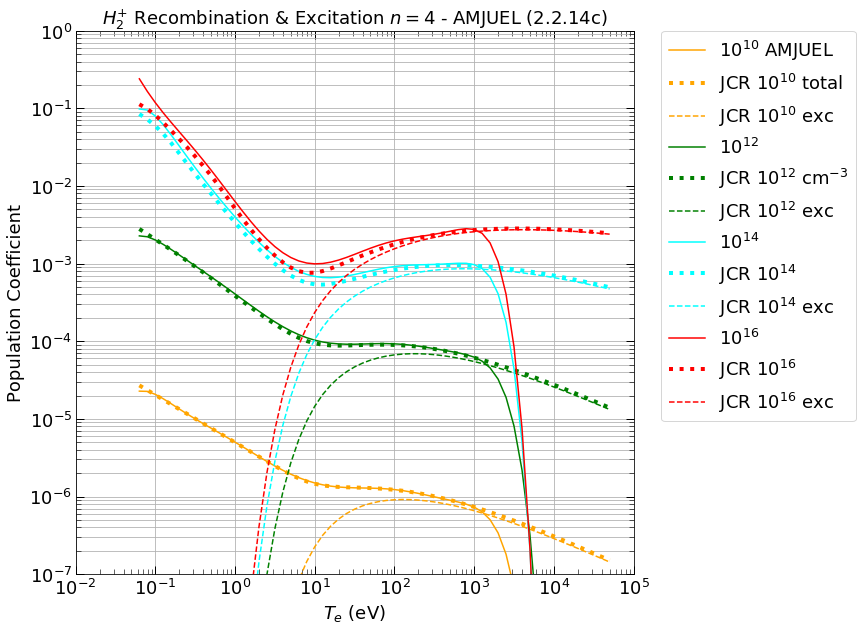

```python
plt.figure(figsize=(10,10))
plt.plot(ehr19Te,data_2214c[0,:],label='$10^{10}$ AMJUEL',color='orange')
plt.plot(ehr19Te,
         (H2p_rec_popn_coef[0,:,2]+H2p_exc_popn_coef[0,:,2]),
         label='JCR $10^{10}$ total',color='orange',lw=4,ls=':')
plt.plot(ehr19Te,
         (H2p_exc_popn_coef[0,:,2]),
         label='JCR $10^{10}$ exc',color='orange',ls='--')
plt.plot(ehr19Te,data_2214c[4,:],label='$10^{12}$',color='green')
plt.plot(ehr19Te,
         (H2p_rec_popn_coef[4,:,2]+H2p_exc_popn_coef[4,:,2]),
         label='JCR $10^{12}$ cm$^{-3}$',color='green',lw=4,ls=':')
plt.plot(ehr19Te,
         (H2p_exc_popn_coef[4,:,2]),
         label='JCR $10^{12}$ exc',color='green',ls='--')
plt.plot(ehr19Te,data_2214c[8,:],label='$10^{14}$',color='cyan')
plt.plot(ehr19Te,
         (H2p_rec_popn_coef[8,:,2]+H2p_exc_popn_coef[8,:,2]),
         label='JCR $10^{14}$',color='cyan',lw=4,ls=':')
plt.plot(ehr19Te,
         (H2p_exc_popn_coef[8,:,2]),
         label='JCR $10^{14}$ exc',color='cyan',ls='--')
plt.plot(ehr19Te,data_2214c[12,:],label='$10^{16}$',color='red')
plt.plot(ehr19Te,
         (H2p_rec_popn_coef[12,:,2]+H2p_exc_popn_coef[12,:,2]),
         label='JCR $10^{16}$',color='red',lw=4,ls=':')
plt.plot(ehr19Te,
         (H2p_exc_popn_coef[12,:,2]),
         label='JCR $10^{16}$ exc',color='red',ls='--')
plt.xlabel('$T_{e}$ (eV)',fontsize=18)
plt.ylabel('Population Coefficient',fontsize=18)
plt.tick_params(which='major',labelsize=18,length=8,width=1,
                direction='in',top='on',right='on')
plt.tick_params(which='minor',length=5,
                direction='in',top='on',right='on')
plt.minorticks_on()
plt.gca().set_yscale('log')
plt.gca().set_xscale('log')
plt.gca().set_xlim((0.01,1.e5))
plt.gca().set_ylim((1.e-7,1.0))
plt.gca().grid(axis='both',which='major')
plt.gca().grid(axis='y',which='minor')
plt.title('$H_{2}^{+}$ Recombination & Excitation $n=4$ - AMJUEL (2.2.14c)',fontsize=18)
plt.legend(bbox_to_anchor=(1.05,1),loc='upper left',borderaxespad=0,fontsize=18)
```

```python
H123 = 'H.12'
reacstr = '2.2.14d'
fit_coef = amjuel.get_AMJUEL_fit(amj_file,H123,reacstr)
data_2214d = np.zeros((num_ne,num_Te))
for jt in range(num_Te):
    for jn in range(num_ne):
        data_2214d[jn,jt] = amjuel.ne_Te_exp_fit(fit_coef,ehr19ne[jn],ehr19Te[jt])
```

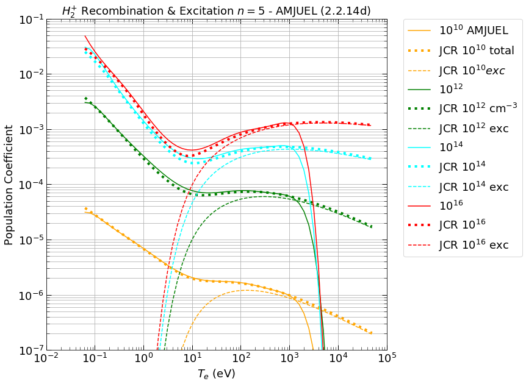

```python
plt.figure(figsize=(10,10))
plt.plot(ehr19Te,data_2214d[0,:],label='$10^{10}$ AMJUEL',color='orange')
plt.plot(ehr19Te,
         (H2p_rec_popn_coef[0,:,3]+H2p_exc_popn_coef[0,:,3]),
         label='JCR $10^{10}$ total',color='orange',lw=4,ls=':')
plt.plot(ehr19Te,
         (H2p_exc_popn_coef[0,:,3]),
         label='JCR $10^{10} exc$',color='orange',ls='--')
plt.plot(ehr19Te,data_2214d[4,:],label='$10^{12}$',color='green')
plt.plot(ehr19Te,
         (H2p_rec_popn_coef[4,:,3]+H2p_exc_popn_coef[4,:,3]),
         label='JCR $10^{12}$ cm$^{-3}$',color='green',lw=4,ls=':')
plt.plot(ehr19Te,
         (H2p_exc_popn_coef[4,:,3]),
         label='JCR $10^{12}$ exc',color='green',ls='--')
plt.plot(ehr19Te,data_2214d[8,:],label='$10^{14}$',color='cyan')
plt.plot(ehr19Te,
         (H2p_rec_popn_coef[8,:,3]+H2p_exc_popn_coef[8,:,3]),
         label='JCR $10^{14}$',color='cyan',lw=4,ls=':')
plt.plot(ehr19Te,
         (H2p_exc_popn_coef[8,:,3]),
         label='JCR $10^{14}$ exc',color='cyan',ls='--')
plt.plot(ehr19Te,data_2214d[12,:],label='$10^{16}$',color='red')
plt.plot(ehr19Te,
         (H2p_rec_popn_coef[12,:,3]+H2p_exc_popn_coef[12,:,3]),
         label='JCR $10^{16}$',color='red',lw=4,ls=':')
plt.plot(ehr19Te,
         (H2p_exc_popn_coef[12,:,3]),
         label='JCR $10^{16}$ exc',color='red',ls='--')
plt.xlabel('$T_{e}$ (eV)',fontsize=18)
plt.ylabel('Population Coefficient',fontsize=18)
plt.tick_params(which='major',labelsize=18,length=8,width=1,
                direction='in',top='on',right='on')
plt.tick_params(which='minor',length=5,
                direction='in',top='on',right='on')
plt.minorticks_on()
plt.gca().set_yscale('log')
plt.gca().set_xscale('log')
plt.gca().set_xlim((0.01,1.e5))
plt.gca().set_ylim((1.e-7,0.1))
plt.gca().grid(axis='both',which='major')
plt.gca().grid(axis='y',which='minor')
plt.title('$H_{2}^{+}$ Recombination & Excitation $n=5$ - AMJUEL (2.2.14d)',fontsize=18)
plt.legend(bbox_to_anchor=(1.05,1),loc='upper left',borderaxespad=0,fontsize=18)
```

The only lines we currently maintain in the H CR model are Balmer $\alpha$ ($n = 3 \rightarrow 2$), $\beta$ ($n = 4 \rightarrow 2$), and $\gamma$ ($n= 5 \rightarrow 2$) and Lyman $\alpha$ ($n = 2 \rightarrow 1$). In the interest of simplicity and consistency, have just copied the transition energies and rates from reactionwrite.web, but using eV here instead of ergs.

```python
Eionize = 13.595
E_32 = Eionize * (1./2.**2 - 1./3.**2)
A_32 = 4.41e7
E_21 = Eionize * (1. - 1./2.**2)
A_21 = 4.699e8
E_42 = Eionize * (1./2.**2 - 1./4.**2)
A_42 = 8.419e6
E_52 = Eionize * (1./2.**2 - 1./5.**2)
A_52 = 2.530e6
```

By convention, the quantity in the files is the emission rate per neutral (here, H$_{2}^{+}$) and per electron. So, we divide out the electron density.

```python
emission_rate_balmer_alpha = np.zeros((num_ne,num_Te))
emission_rate_balmer_beta = np.zeros((num_ne,num_Te))
emission_rate_balmer_gamma = np.zeros((num_ne,num_Te))
emission_rate_lyman_alpha = np.zeros((num_ne,num_Te))
for jn in range(num_ne):
    emission_rate_balmer_alpha[jn,:] = E_32*A_32*H2p_exc_popn_coef[jn,:,3-2]/ehr19ne[jn]
    emission_rate_balmer_beta[jn,:] = E_42*A_42*H2p_exc_popn_coef[jn,:,4-2]/ehr19ne[jn]
    emission_rate_balmer_gamma[jn,:] = E_52*A_52*H2p_exc_popn_coef[jn,:,5-2]/ehr19ne[jn]
    emission_rate_lyman_alpha[jn,:] = E_21*A_21*H2p_exc_popn_coef[jn,:,2-2]/ehr19ne[jn]
```

In the previous DEGAS 2 model for molecular ion dissociation, only an $n=3$ excited product was included, with the rate derived from JLEP reaction (2.2.13). Two points should be noted with regard to this comparison. First, the previous model set $n=3$ rate as 0.174 times the (2.2.13), based on reasoning described in Reiter's 1992 PSI paper; the effective ratio (without CR effects) now is $(2/3)^{3} = 0.2963$. Second, the current procedure also populates higher states, which can decay to $n=3$ even in the coronal limit. For these reasons, the previous rate is well below the coronal limit of the new one.

Read in the previous data from the netCDF file and make a comparison plot:

```python
h2pdis_n3_nc = xs.xs_netCDF.read_ncfile('h2pdis_n3',data_dir)
h2pdis_n3_nc.xs.list_vars()
print('  ')
h2pdis_n3_nc.xs.print_var(3)
old_Dalpha_rate = h2pdis_n3_nc.xs.get_var4plot(3)
```

```
 j              Name                   Units
 0 reaction_rate                  cm^3/s
 1 background_energy_loss_rate    eV*cm^3/s
 2 dissociation_energy            eV
 3 emission_rate                  eV*cm^3/s
 4 wavelength_H_alpha             Angstroms
 5 wavelength_D_alpha             Angstroms
 6 wavelength_T_alpha             Angstroms

Dependent variable:  emission_rate  Units:  eV*cm^3/s
 Multiplier:  1.60218e-25  Spacing:  log

  Indep. var.     Units    Multiplier  Spacing     Min.        Max.
temperature     eV         1.60218e-19 log      1.00000e+00 5.01187e+04
```

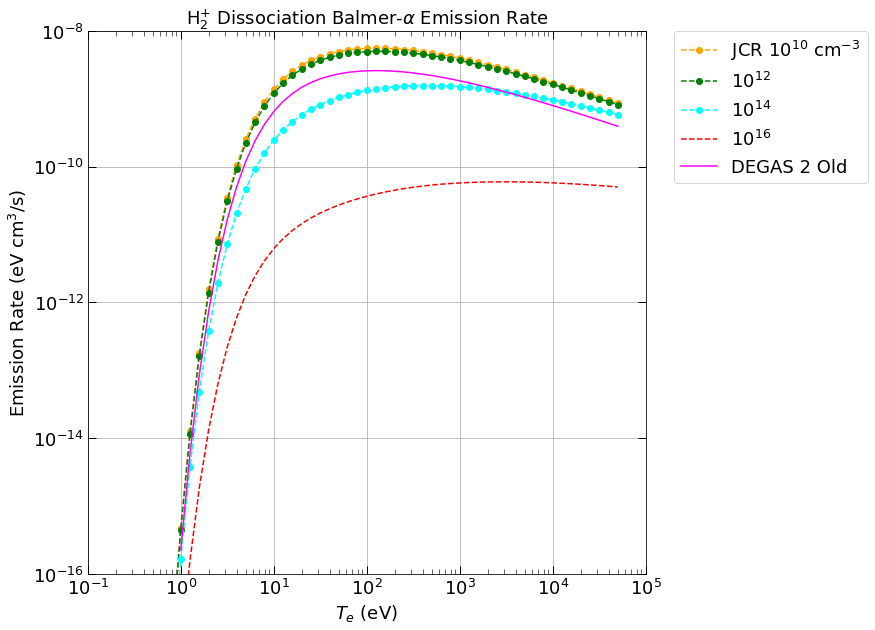

```python
plt.figure(figsize=(10,10))
plt.plot(ehr19Te,
         emission_rate_balmer_alpha[0,:],'-o',
         label='JCR $10^{10}$ cm$^{-3}$',color='orange',ls='--')
plt.plot(ehr19Te,
         emission_rate_balmer_alpha[4,:],'-o',
         label='$10^{12}$',color='green',ls='--')
plt.plot(ehr19Te,
         emission_rate_balmer_alpha[8,:],'-o',
         label='$10^{14}$',color='cyan',ls='--')
plt.plot(ehr19Te,
         emission_rate_balmer_alpha[12,:],
         label='$10^{16}$',color='red',ls='--')
plt.plot(old_Dalpha_rate[0],old_Dalpha_rate[1],label='DEGAS 2 Old',color='magenta')
plt.xlabel('$T_{e}$ (eV)',fontsize=18)
plt.ylabel('Emission Rate (eV cm$^{3}$/s)',fontsize=18)
plt.tick_params(which='major',labelsize=18,length=8,width=1,
                direction='in',top='on',right='on')
plt.tick_params(which='minor',length=5,
                direction='in',top='on',right='on')
plt.minorticks_on()
plt.gca().set_yscale('log')
plt.gca().set_xscale('log')
plt.gca().set_xlim((0.1,1.e5))
plt.gca().set_ylim((1.e-16,1.e-8))
plt.gca().grid(axis='both',which='major')
plt.gca().grid(axis='y',which='minor')
plt.title(r'H$_{2}^{+}$ Dissociation Balmer-$\alpha$ Emission Rate',fontsize=18)
plt.legend(bbox_to_anchor=(1.05,1),loc='upper left',borderaxespad=0,fontsize=18)
```

Writing the data to the netCDF file consists of two steps. The first involves defining the independent and dependent variables and then setting up the data table that holds all of the actual rate data.

The variables being written to this file are:

1. Reaction rate(temperature,density)
2. Dissociation energy (scalar)
3. Background energy loss rate (temperature,density)
4. Emission rate (temperature, density) - default rate is for Balmer-$\alpha$.
5. Emission rate Lyman-$\alpha$ (temperature, density)
6. Emission rate Balmer-$\beta$ (temperature, density)
7. Emission rate Balmer-$\gamma$ (temperature, density)
8. Wavelength H$_{\alpha}$ (emitter mass)
9. Wavelength D$_{\alpha}$ (emitter mass)
10. Wavelength T$_{\alpha}$ (emitter mass)
11. Wavelength Lyman-$\alpha$
12. Wavelength Balmer-$\beta$
13. Wavelength Balmer-$\gamma$

As above, there are num_ne density values and num_Te temperature values. Note that we change from using (density,temperature) in these notebooks to (temperature,density) in the netCDF files. The latter is to be consistent with the convention in the H CR files, such as hionize5.nc. The swap is effected by sending the transpose of the data arrays in the set_data method calls below. We use 4 values of the emitter mass to connect the emitting species with its wavelength.

This initialization call sets the name of the reaction and the netCDF file, and specifies the number of dependent variables.

```python
h2pdis = xs.xs_data('h2pdis_jcr',13)
```

Now, loop through the variables, providing the name, evaluation name (not really used), dimensions, units, multiplier, independent variable minimum and maximum, and the spacing method used for interpolation.

```python
h2pdis.set_var(0,['reaction_rate','temperature','density'],'table',
              [num_Te,num_ne],['cm^3/s','eV','cm^-3'],
              [1.e-6,xs.electron_charge,1.e6],
              [ehr19Te[0],ehr19ne[0]],
              [ehr19Te[-1],ehr19ne[-1]],
              ['log']*3)
```

```python
h2pdis.set_var(1,['dissociation_energy'],'table',
              [],['eV'],
              [xs.electron_charge],
              [],
              [],
              ['linear'])
```

```python
for j in range(2,7):
    rate_names = ['background_energy_loss_rate','emission_rate',
           'emission_rate_Lyman_alpha','emission_rate_Balmer_beta',
           'emission_rate_Balmer_gamma']
    h2pdis.set_var(j,[rate_names[j-2],'temperature','density'],'table',
                  [num_Te,num_ne],['eV*cm^3/s','eV','cm^-3'],
                  [1.e-6*xs.electron_charge,xs.electron_charge,1.e6],
                  [ehr19Te[0],ehr19ne[0]],
                  [ehr19Te[-1],ehr19ne[-1]],
                  ['log']*3)
```

```python
for j in range(7,10):
    B_wave_names = ['wavelength_H_alpha','wavelength_D_alpha','wavelength_T_alpha']
    #
    # Copied these from existing files
    #
    wave_mins = [1.5e-27,3.2e-27,4.85e-27]
    wave_maxs = [1.8e-27,3.5e-27,5.15e-27]
    h2pdis.set_var(j,[B_wave_names[j-7],'emitter_mass'],'table',
                  [4],['Angstroms','kilograms'],
                  [1.e-10,1.],
                  [wave_mins[j-7]],
                  [wave_maxs[j-7]],
                  ['linear']*2)
```

```python
for j in range(10,13):
    wave_names = ['wavelength_Lyman_alpha','wavelength_Balmer_beta',
                  'wavelength_Balmer_gamma']
    #
    # Note that the use of table_external here is only
    # for consistency with reactionwrite.web; the particular
    # value has no meaning since we are not using ratecalc here.
    #
    h2pdis.set_var(j,[wave_names[j-10]],'table_external',
                  [],['Angstroms'],
                  [1.e-10],
                  [],
                  [],
                  ['linear'])
```

Fill in the data table.

The wavelength values are entered manually by copying them from reactionwrite.web.

```python
h2pdis.set_data(0,D_H2p.T)
h2pdis.set_data(1,E_diss)
h2pdis.set_data(2,E_loss_rate.T)
h2pdis.set_data(3,emission_rate_balmer_alpha.T)
h2pdis.set_data(4,emission_rate_lyman_alpha.T)
h2pdis.set_data(5,emission_rate_balmer_beta.T)
h2pdis.set_data(6,emission_rate_balmer_gamma.T)
h2pdis.set_data(7,np.array([0.,6.56280e3,6.56280e3,0.]))  # H Balmer-alpha
h2pdis.set_data(8,np.array([0.,6.56104e3,6.56104e3,0.]))  # D
h2pdis.set_data(9,np.array([0.,6.56045e3,6.56045e3,0.]))  # T
h2pdis.set_data(10,1.215668e3)  # Lyman-alpha
h2pdis.set_data(11,4.861e3)     # Balmer-beta
h2pdis.set_data(12,4.341e3)     # Balmer-gamma
```

Now open the netCDF file, write in the data using the h2pdis xs_data data structures, and close the file.

```python
work_dir = './'
h2pdis_nc = xs.xs_netCDF.write_ncfile(h2pdis,work_dir,
                        'Reference atomic physics data for a reaction in degas 2',
                        'V. 1.0, effective H2+ dissociation with CR effects')
h2pdis_nc.close()
```